# Linear Regression Model and Model Evaluation

#### Hemant Thapa

This is an open-research conducted on Machine Learning, All material used during research are free of cost and open-source softwares, such as Jupyter Notebook, pandas, Statsmodels Python in-built libraries, Sklearn, Matplotlib, Seaborn, Previous publish journals, youtube videos and website has been provided on Reference.

### Introduction to Linear Regression Analysis

Linear regression is an algorithm that provides a linear relationship between an independent variable and a dependent variable to predict the outcome of future events. It is a statistical method used in data science and machine learning for predictive analysis.

The independent variable is also the predictor or explanatory variable that remains unchanged due to the change in other variables. However, the dependent variable changes with fluctuations in the independent variable. The regression model predicts the value of the dependent variable, which is the response or outcome variable being analyzed or studied.

Thus, linear regression is a supervised learning algorithm that simulates a mathematical relationship between variables and makes predictions for continuous or numeric variables such as sales, salary, age, product price, etc.

This analysis method is advantageous when at least two variables are available in the data, as observed in stock market forecasting, portfolio management, scientific analysis, etc.

#### 1. Easy implementation

The linear regression model is computationally simple to implement as it does not demand a lot of engineering overheads, neither before the model launch nor during its maintenance.

#### 2. Interpretability

Unlike other deep learning models (neural networks), linear regression is relatively straightforward. As a result, this algorithm stands ahead of black-box models that fall short in justifying which input variable causes the output variable to change.

#### 3. Scalability

Linear regression is not computationally heavy and, therefore, fits well in cases where scaling is essential. For example, the model can scale well regarding increased data volume (big data).

#### 4. Optimal for online settings

The ease of computation of these algorithms allows them to be used in online settings. The model can be trained and retrained with each new example to generate predictions in real-time, unlike the neural networks or support vector machines that are computationally heavy and require plenty of computing resources and substantial waiting time to retrain on a new dataset. All these factors make such compute-intensive models expensive and unsuitable for real-time applications.

The above features highlight why linear regression is a popular model to solve real-life machine learning problems.

Functinal programming has been used to calculate Least square method and R square value, it will be done without ML libraries

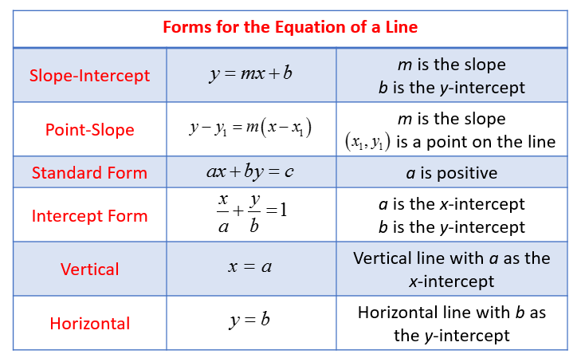

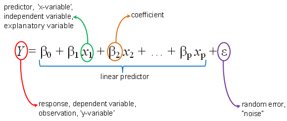

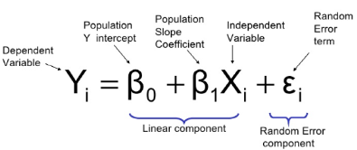

#### *Machine Learning - Model Evaluation

1. Least square method
2. R square or coefficient of determinaton
3. Mean absolute error (MAE)
4. Mean square error (MSE)
5. Mean Absolute Percentage error (MAPE)

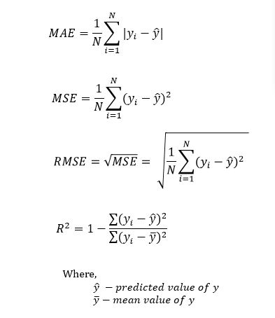

#### *Best Practices of Linear Regression

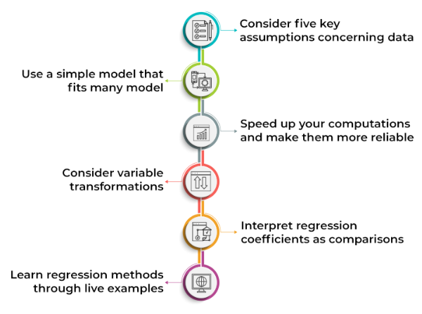

### 1. Key Assumption

Linear regression analysis can be practical and be performed accurately when the data abides by a set of rules. These are referred to as key assumptions concerning the data.

#### 1.1. Linear relationship

The first important assumption of linear regression is that the dependent and independent variables should be linearly related. The relationship can be determined with the help of scatter plots that help in visualization. Also, one needs to check for outliers as linear regression is sensitive to them.

#### 1.2. Normal distribution of residuals

The second assumption relates to the normal distribution of residuals or error terms, i.e., if residuals are non-normally distributed, the model-based estimation may become too wide or narrow. The non-normal distribution also underscores that you need to closely observe some unusual data points to make a good model.

#### 1.3. Multicollinearity

The third assumption relates to multicollinearity, where several independent variables in a model are highly correlated. More correlated variables make it difficult to determine which variable contributes to predicting the target variable. Also, standard errors inevitably increase due to correlated variables.

Moreover, with such a robust variable correlation, the predicted regression coefficient of a correlated variable further depends on the other variables available in the model, leading to wrong conclusions and poor performance. The goal, therefore, is to have minimal or lesser multicollinearity.

#### 1.4. Autocorrelation

One fundamental assumption of linear regression specifies that the given dataset should not be autocorrelated. This mostly happens when residuals or error terms are not independent of each other.

In other words, the situation arises when the value of f(a+1) is not independent of the value of f(a). For example, in the case of stock prices, the price of one stock depends on the cost of the previous one.

#### 1.5. Homoscedasticity

Another assumption of linear regression analysis is referred to as homoscedasticity. Homoscedasticity relates to cases where the residuals (error terms) between the independent and dependent variables remain the same for all independent variable values.

In simple words, the residuals or error terms must have ‘constant variance.’ If not, it leads to an unbalanced scatter of residuals, known as heteroscedasticity. With heteroscedasticity, you cannot trust the results of the regression analysis.

### 2. Use Simple Model

The common misconception is that complex problems require complex regression models. However, research has identified that simpler models offer precise predictions as they effectively show how well the data fit with the models.

Furthermore, as most models have similar explanatory abilities, simple linear regression models are likely the best choice. Start with a simple regression model and make it complex as per the need. This has its implications, as the more complex the model is, the more tailored the model will be to the specific dataset. As a result, generalizability suffers.

One must verify, validate, and ensure that the added complexity produces narrower prediction intervals. Also, keep checking the predicted R-squared value rather than chasing the high R-squared range. R-squared is a statistical measure, also termed a coefficient of determination, which evaluates how close the data (data points) are to the fitted regression line.

### 3. Speed up your computations and make them more reliable

The practice improves how quickly computing systems process the data while using a linear regression model. You may incur additional startup costs associated with data preparation or model complexity by speeding up the computations and making the model run faster. Some methods to boost model speed include:

Data subsetting Subsetting allows you to explore data with potentially more models, .and separate analysis reveals variations across these subsets.

Predictive simulation (Fake data) You can resolve glitches in the code or the model fit by employing predictive simulation. This can be achieved using Bayesian generalized linear models that help to make probabilistic predictions via simulations. Also, predictive simulation helps in comparing the data to the fitted model’s prediction.

Fake-data simulation enables you to verify the correctness of the code.

Graph the relevant and not the irrelevant Graphing is a crucial tool used for visualization while performing regression analysis. The objective of these graphs is to communicate the information to oneself or a wider audience. Displaying the raw data (exploratory data analysis [EDA]) is the first graphing step.

Graph the model Fitted model graphs have the following representation:

The data plots overlay show the model fit. Graphed sets of estimated parameters. Plot predicted datasets and compare them to actual data. Graph the data Real-world data is complex as it has multiple dimensions. Hence, making different graphs and observing the model from different vantage points is essential. In other words, use a series of graphs for better data visualizations instead of depending on a single image.

Avoid graphing irrelevant data Experts in the field know the importance of plotting raw data and regression diagnostics (residual variance). Although such plots help determine the usability of the model in predicting individual data points, the plots do not satisfy the assumptions of linearity, normality, etc., in regression stated earlier.

Implying, focus on plotting graphs that you are capable of explaining rather than graphing irrelevant data that are unexplainable.

### 4. Consider variable transformations

Consider transforming every variable under consideration in the regression model. Known transformation ways include:

Log transformations: Derive logarithms of positive variables that enable you to consider multiplicative models. Standardization: Standardizing allows straightforward interpretation and scaling of all the statistics or coefficients in a model. It ensures whether the model data is within a specific range or scale. Transform first, model later (multilevel modeling): This practice makes model coefficients comparable, and the model makes better sense. Additionally, consider plotting raw data and residuals while performing the transformations.

The above transformations are univariate. However, interactions and predictors formed by combining inputs can be transformed too; for example, combining all the survey responses creates a total score. Transformations aim to create fit models that include relevant information and can be compared to data.

### 5. Interpret regression coefficients as comparisons

Interpreting regression coefficients is critical to understanding the model. Let’s consider a sample linear regression equation,

Monthly wage = – 20 + 0.7 * height + error

(Where wage = per $1k and height = inches)

The model tells us that taller people in this sample earn more on average. In other words, the model reveals the average difference in earnings between two people who have some height difference.

Interpreting regression in the context of comparisons has the following benefits:

Interpretation as a comparison: Comparisons explain the model without the need for any causal assumptions. Complicated regressions can be built using simpler models: For complex regressions, start with simpler models and make/add adjustments as needed. Comparisons help in causal inference: Deriving the causal impact on an outcome (causal inference) becomes possible with comparative interpretation.

### 6. Learn regression methods through live examples

Linear regression is best learned when you apply complex statistical methods to real-life problems that you care about.

The process begins with proper data collection procedures related to the population of interest. Then, you need to determine the objective of data collection and analysis. This implies identifying what you want to achieve and is it achievable with the data at hand. Finally, gain a complete statistical understanding of your data through simulations and visualizations.

### 1. Least square method

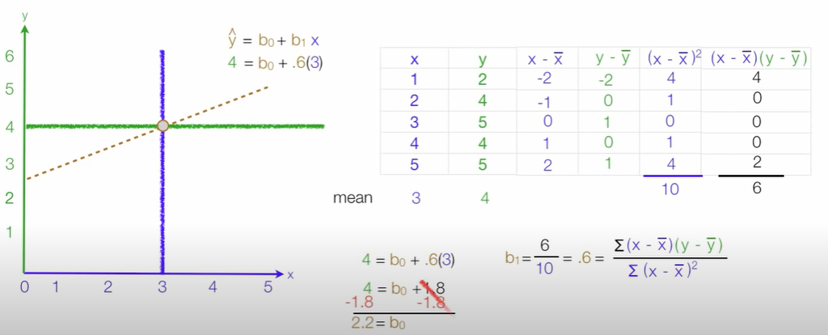

```
1. x mean: 3.0
2. y mean: 4.0
3. (x-x_mean): [-2.0, -1.0, 0.0, 1.0, 2.0]
4. (y-y_mean): [-2.0, 0.0, 1.0, 0.0, 1.0]
5. (x - x_mean)^2: [4.0, 1.0, 0.0, 1.0, 4.0]
6. (x-x_mean)(y-y_mean): [4.0, -0.0, 0.0, 0.0, 2.0]
7. b1: 0.6
8. bo: 2.2
9. y = 2.2 + 0.6x
```

### 2. R-Squared

#### - R square tells us, how well a regression line predicts or estimates actual values.

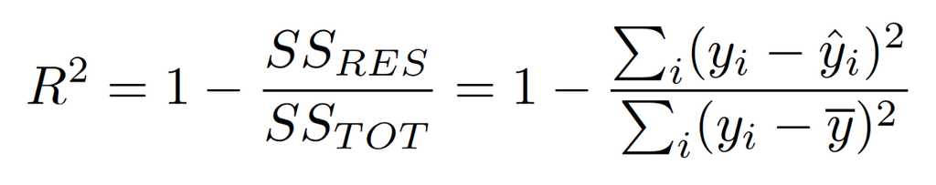

#### - Adjusted R squared

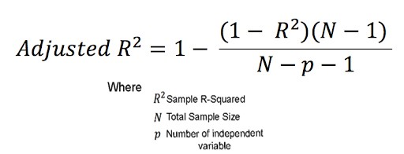

#### 1. To calculate R squared, we take actual values and we determine the mean of those values.

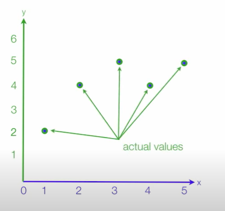

#### 2. We look at the distance from the actual value to the mean, so we have distance to the actual value of the mean

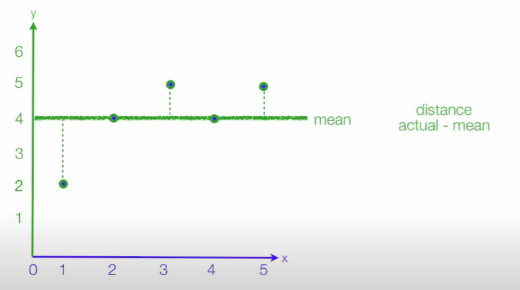

#### 3. We draw a regression line and we comes up with estimated values and these are all estimated values.

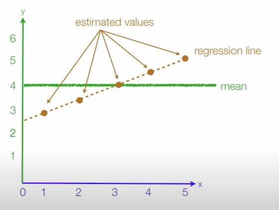

#### 4. we take distance to estimated value of the mean. we compare this with the distance of the actual to the mean.

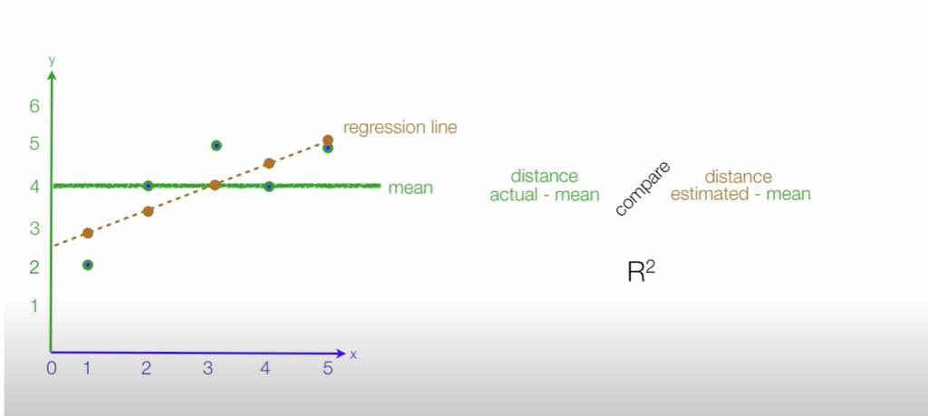

#### 5. Defininf function for R Squared and calulating

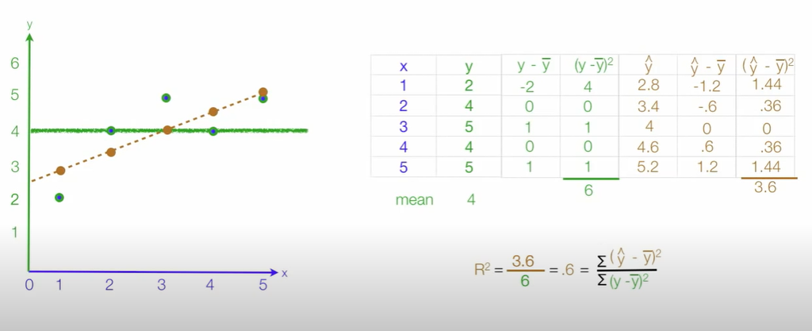

```
1. x mean: 3.0
2. y mean: 4.0

3. (y - y_mean): [-2.0, 0.0, 1.0, 0.0, 1.0]
4. total of (y - y_mean): 0.0

5. (y-y_mean)(y-y_mean): [4.0, 0.0, 1.0, 0.0, 1.0]
6. total of (y-y_mean)(y-y_mean): 6.0

7. y estimated: [2.8000000000000003, 3.4000000000000004, 4.0, 4.6, 5.2]
8. total of y estimated: 20.0

9. (y_estimated - y_mean): [-1.1999999999999997, -0.5999999999999996, 0.0, 0.5999999999999996, 1.2000000000000002]
10. total of (y_estimated - y_mean): 4.440892098500626e-16

11. (y_estimated - y_mean)^2:[1.4399999999999993, 0.3599999999999996, 0.0, 0.3599999999999996, 1.4400000000000004]
12. total of (y_estimated - y_mean)^2: 3.5999999999999988

13. R squared: 0.6
```

#### 6. Graph ploted using R squared 0.6

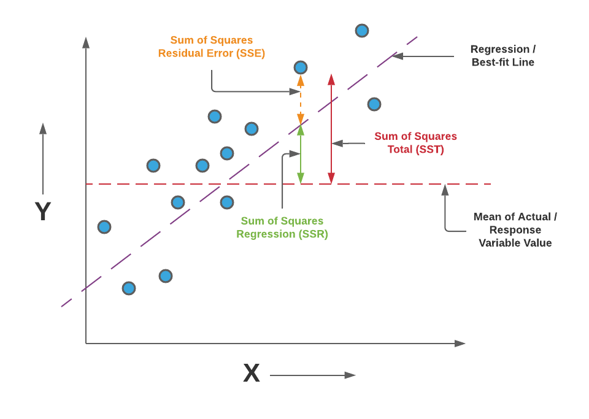

```
[2.8000000000000003, 3.4000000000000004, 4.0, 4.6, 5.2]
```

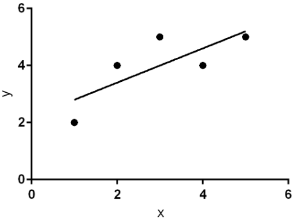

[figure not shown]

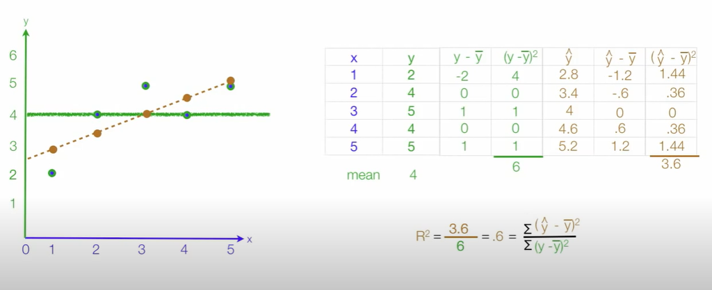

[figure not shown]

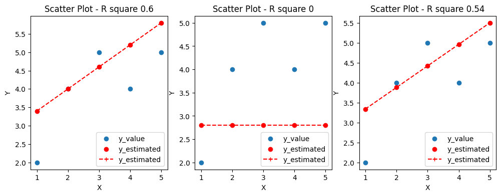

### 3. Linear regression validation using ML Model from Sklearn

#### 3.1 x-value and y-value for linear model

2-dimensional array, specifically a list of lists, in which each inner list contains only one element. In other words, it's a matrix with one column and 5 rows.

The reshape(-1,1) means it will reshape the numpy array x into 2-D array where -1 means it will automatically decide the number of rows and 1 means it will have 1 column.

```
array([[1],
       [2],
       [3],
       [4],
       [5]])
```

```
[[1]
 [2]
 [3]
 [4]
 [5]]
```

1. The difference between [[1], [2], [3], [4], [5]] and [[1] [2] [3] [4] [5]] is just the formatting. They both represent the same 2-dimensional array with the same elements.
2. [[1], [2], [3], [4], [5]] is a list of lists, where each inner list has only one element and it is in a single line.
3. [[1] [2] [3] [4] [5]] is a list of lists, where each inner list has only one element and it is in multiple lines.

In terms of functionality, they are identical and can be used interchangeably in a program. For example, in python you can use numpy.array() to convert both of them into numpy array and use it for various operation.

```
array([[2],
       [4],
       [5],
       [4],
       [5]])
```

```
[[1]
 [2]
 [3]
 [4]
 [5]]

[[2]
 [4]
 [5]
 [4]
 [5]]

[[2.8]
 [3.4]
 [4. ]
 [4.6]
 [5.2]]
```

```
LinearRegression()
```

```
Coefficeint:[0.6]
Intercept: 2.2
```

#### Calulating R - Squared using Sklearn

```
0.6000000000000001
```

```
R squared with functional programming: 0.6
Sklearn - R Square: 0.6000000000000001
```

```
1.0
```

#### Formula for Adjusted R^2

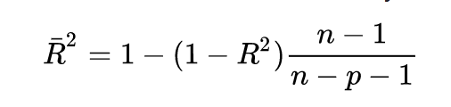

```
(5, 1)
```

```
(5, 1)
```

```
(5, 1)
```

#### Calculate adjusted R square

```
0.6000000000000001
```

```
0.4666666666666668
```

```
(array([4.5]), array([0.12402706]))
```

```
4.5
```

```
0.12403
```

## MSE

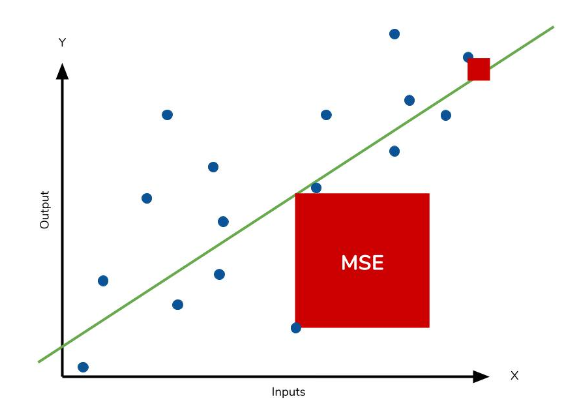

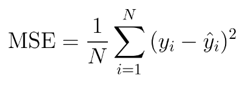

```
[[2.8]
 [3.4]
 [4. ]
 [4.6]
 [5.2]]

Mean square error:0.47999999999999987
```

## MSLE

```
Mean squared log error: 0.023876147746446467
```

## MAE

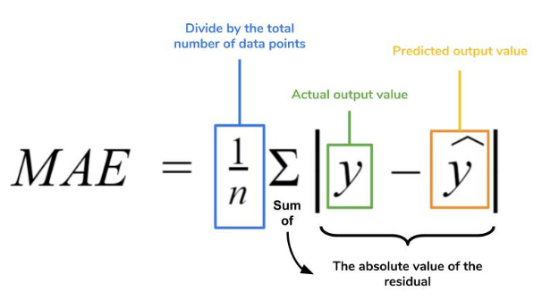

The mean absolute error (MAE) is the simplest regression error metric to understand. We’ll calculate the residual for every data point, taking only the absolute value of each so that negative and positive residuals do not cancel out. We then take the average of all these residuals. Effectively, MAE describes the typical magnitude of the residuals.

```
Mean Absolute error: 0.6399999999999999
```

## MAPE

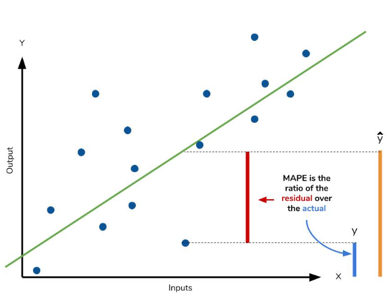

[output not shown]

## RMSLE

```
0.1545190853792711
```

#### Statsmodels

In order to find the R-squared value using the statsmodel library, you can use the OLS (Ordinary Least Squares) class from the statsmodels.regression.linear_model module to fit a linear regression model to your data, and then use the rsquared attribute of the resulting model to find the R-squared value.

```
The residuals are normally distributed.
```

```
                            OLS Regression Results
==============================================================================
Dep. Variable:                      y   R-squared:                       0.600
Model:                            OLS   Adj. R-squared:                  0.467
Method:                 Least Squares   F-statistic:                     4.500
Date:                Tue, 07 Mar 2023   Prob (F-statistic):              0.124
Time:                        14:15:58   Log-Likelihood:                -5.2598
No. Observations:                   5   AIC:                             14.52
Df Residuals:                       3   BIC:                             13.74
Df Model:                           1
Covariance Type:            nonrobust
==============================================================================
                 coef    std err          t      P>|t|      [0.025      0.975]
------------------------------------------------------------------------------
const          2.2000      0.938      2.345      0.101      -0.785       5.185
x1             0.6000      0.283      2.121      0.124      -0.300       1.500
==============================================================================
Omnibus:                          nan   Durbin-Watson:                   2.017
Prob(Omnibus):                    nan   Jarque-Bera (JB):                0.570
Skew:                           0.289   Prob(JB):                        0.752
Kurtosis:                       1.450   Cond. No.                         8.37
==============================================================================

Notes:
[1] Standard Errors assume that the covariance matrix of the errors is correctly specified.
```

```
array([2.8, 3.4, 4. , 4.6, 5.2])
```

1. The add_constant function is used to add a column of ones to the independent variable(s) in a linear regression model. This is necessary when using the OLS class from the statsmodels.regression.linear_model module to fit a linear regression model because this class requires that the independent variable(s) include an intercept term, which is represented by a column of ones.
2. In a linear regression model with one independent variable, the equation of the line is represented by the following equation: y = b0 + b1*x
3. Where b0 is the y-intercept and b1 is the slope of the line. The y-intercept is the point where the line crosses the y-axis and it is usually represented by a constant term in the equation.
4. When there are multiple independent variables, the equation becomes:

y = b0 + b1x1 + b2x2 + .....+ bn*xn

5. The add_constant function is used to add a column of ones to the independent variable(s) and the b0 is the coefficient of the column of ones.

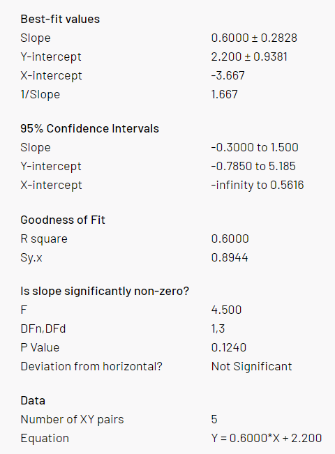

#### Observation for R square value

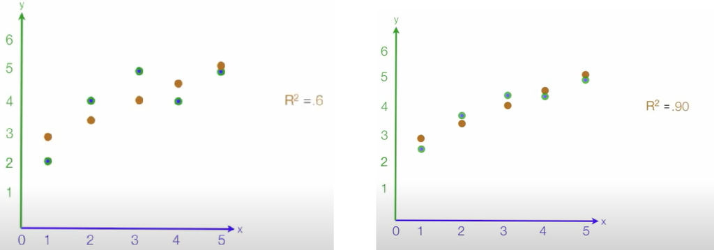

2. The actuals and estimated were closer together r squared maybe would approach 0.9 and in fact they're exactly the same R squared to one

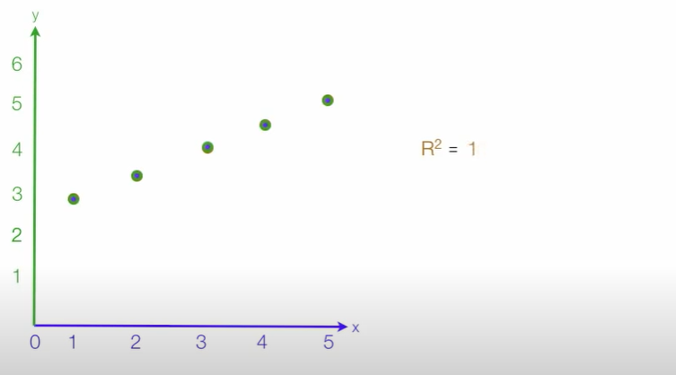

### Breakdown of formula used in R Squared def function

#### Estimated value using for loop

```
2.8000000000000003
3.4000000000000004
4.0
4.6
5.2
```

```
[2.8000000000000003, 3.4000000000000004, 4.0, 4.6, 5.2]
```

#### y estimated - y mean

```
-1.1999999999999997
-0.5999999999999996
0.0
0.5999999999999996
1.2000000000000002
```

```
[-1.1999999999999997, -0.5999999999999996, 0.0, 0.5999999999999996, 1.2000000000000002]
```

```
4.440892098500626e-16
```

#### (y estimated - y mean)(y estimated - y mean)

```
1.4399999999999993
0.3599999999999996
0.0
0.3599999999999996
1.4400000000000004
```

```
[1.4399999999999993, 0.3599999999999996, 0.0, 0.3599999999999996, 1.4400000000000004]
```

### Example 1 - Missing value with single columns

#### 1. We have simple dictoanry dataset, which contains two key "x" and "y". where y have three missing value (None)

```
x : [1, 2, 3, 4, 5, 6, 7, 8]
y : [1, 2, 3, 4, 5, None, None, None]
```

#### 2. Now data is converted into DataFrame using pandas and transpose row and columns

|  | 0 | 1 | 2 | 3 | 4 | 5 | 6 | 7 |
| --- | --- | --- | --- | --- | --- | --- | --- | --- |
| x | 1.0 | 2.0 | 3.0 | 4.0 | 5.0 | 6.0 | 7.0 | 8.0 |
| y | 1.0 | 2.0 | 3.0 | 4.0 | 5.0 | NaN | NaN | NaN |

#### 3. Creating ML Model for prediction

```
[6. 7. 8.]
```

#### 4. Imputing missing values

|  | 0 | 1 | 2 | 3 | 4 | 5 | 6 | 7 |
| --- | --- | --- | --- | --- | --- | --- | --- | --- |
| x | 1.0 | 2.0 | 3.0 | 4.0 | 5.0 | 6.0 | 7.0 | 8.0 |
| y | 1.0 | 2.0 | 3.0 | 4.0 | 5.0 | 6.0 | 7.0 | 8.0 |

### Example 2 - Missing values with dual columns

#### 1. We have simple dictoanry dataset, which contains two key "x", "y" and "z". where y and z have three missing value (None)

```
x : [1, 2, 3, 4, 5, 6, 7, 8]
y : [1, 2, 3, 4, 5, None, None, None]
z : [1, None, None, None, 5, 6, 7, 8]
```

#### 2. Create a DataFrame from your data

|  | 0 | 1 | 2 | 3 | 4 | 5 | 6 | 7 |
| --- | --- | --- | --- | --- | --- | --- | --- | --- |
| x | 1.0 | 2.0 | 3.0 | 4.0 | 5.0 | 6.0 | 7.0 | 8.0 |
| y | 1.0 | 2.0 | 3.0 | 4.0 | 5.0 | NaN | NaN | NaN |
| z | 1.0 | NaN | NaN | NaN | 5.0 | 6.0 | 7.0 | 8.0 |

#### 3. Get the indices of the missing values in the "y" and "z" columns:

#### 4. Split the data into the non-missing values for "y" and "z" columns:

#### 5. Create the linear regression model

#### 6. Fit the model with the non-missing data

```
LinearRegression()
```

#### 7. Use the model to predict the missing values

#### 8. Update the dataframe with the predicted values

|  | 0 | 1 | 2 | 3 | 4 | 5 | 6 | 7 |
| --- | --- | --- | --- | --- | --- | --- | --- | --- |
| x | 1.0 | 2.0 | 3.0 | 4.0 | 5.0 | 6.0 | 7.0 | 8.0 |
| y | 1.0 | 2.0 | 3.0 | 4.0 | 5.0 | 6.0 | 7.0 | 8.0 |
| z | 1.0 | 2.0 | 3.0 | 4.0 | 5.0 | 6.0 | 7.0 | 8.0 |

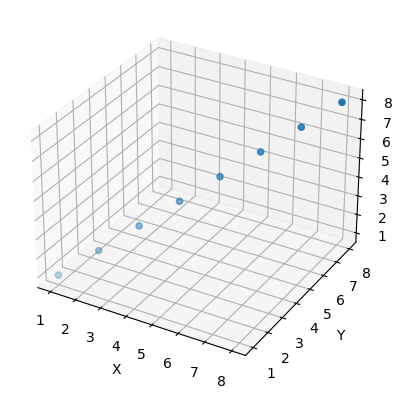

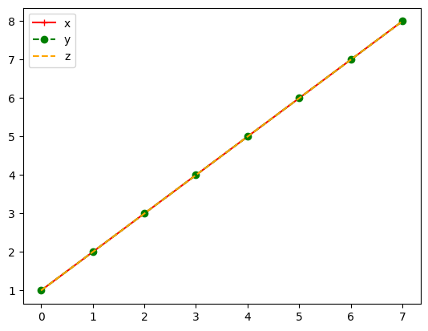

#### Example 3 - Missing value with triple columns

In a multiple linear regression with four independent variables (also known as predictors or features), the goal is to find the best linear relationship between these four variables and the dependent variable (also known as the response or target). This relationship can be represented by a linear equation in the form of

y = b0 + b1x1 + b2x2 + b3x3 + b4x4

1. Where y is the dependent variable, x1, x2, x3, x4 are the independent variables and b0, b1, b2, b3, b4 are the coefficients or parameters of the model.
2. The coefficients are chosen to minimize the sum of the squared residuals (also known as the "least squares" method). This method is used to find the line of best fit which minimizes the difference between the predicted values and the actual values.
3. Once the model is trained, it can be used to make predictions about the dependent variable based on the values of the independent variables.
4. It's important to note that all independent variables should be independent of each other and should not contain multicollinearity, as this can affect the accuracy of the model.

```
a : [1, 2, 3, 4, 5, 6, 7, 8]
b : [1, 2, 3, 4, 5, 6, None, 8]
c : [1, 2, None, 4, None, 6, 7, 8]
d : [1, 2, 3, 4, 5, None, 7, 8]
```

#### 2. Create a DataFrame from data

|  | a | b | c | d |
| --- | --- | --- | --- | --- |
| 0 | 1 | 1.0 | 1.0 | 1.0 |
| 1 | 2 | 2.0 | 2.0 | 2.0 |
| 2 | 3 | 3.0 | NaN | 3.0 |
| 3 | 4 | 4.0 | 4.0 | 4.0 |
| 4 | 5 | 5.0 | NaN | 5.0 |
| 5 | 6 | 6.0 | 6.0 | NaN |
| 6 | 7 | NaN | 7.0 | 7.0 |
| 7 | 8 | 8.0 | 8.0 | 8.0 |

#### 3. Get the indices of the missing values in the "b", "c", "d" columns

#### 4. Split the data into the non-missing values for "b", "c", "d" columns

#### 5. Create the linear regression model

#### 6. Fit the model with the non-missing data

```
LinearRegression()
```

#### 7. Use the model to predict the missing values

#### 8. Update the dataframe with the predicted values

|  | 0 | 1 | 2 | 3 | 4 | 5 | 6 | 7 |
| --- | --- | --- | --- | --- | --- | --- | --- | --- |
| a | 1.0 | 2.0 | 3.0 | 4.0 | 5.0 | 6.0 | 7.0 | 8.0 |
| b | 1.0 | 2.0 | 3.0 | 4.0 | 5.0 | 6.0 | 7.0 | 8.0 |
| c | 1.0 | 2.0 | 3.0 | 4.0 | 5.0 | 6.0 | 7.0 | 8.0 |
| d | 1.0 | 2.0 | 3.0 | 4.0 | 5.0 | 6.0 | 7.0 | 8.0 |

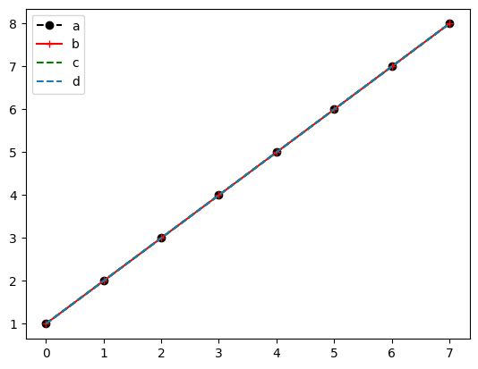

### Example 4 - Multiple missing Values (SimpleImputer Model)

SimpleImputer is a basic imputer which replaces the missing values with a specific value or the mean/median/most_frequent value of the feature.

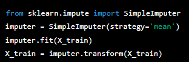

#### Simple imputation is a technique that is used to replace missing values in a dataset with a chosen value, such as the mean, median, or most frequent value of the feature.

There are several reasons why simple imputation is used for multiple missing values:

1. Ease of implementation: Simple imputation is relatively straightforward to implement and does not require a lot of computational resources. It is a quick and easy way to handle missing values in a dataset.
2. Interpretability: Simple imputation methods such as mean or median are easy to interpret and understand. It is clear what value is being used to replace the missing data.
3. Assumptions: Simple imputation methods make assumptions about the underlying distribution of the data. For example, if the data is normally distributed, then the mean is a good estimate of the central tendency of the data.
4. Effective for small amount of missing data: Simple imputation methods are most effective when the amount of missing data is relatively small. This method is not as effective when there is a large amount of missing data, as it can lead to bias in the estimates.
5. Works well with other techniques: Simple imputation is often used in combination with other techniques such as data visualization, outlier detection, and feature engineering. It can be a useful preprocessing step before applying more advanced techniques.

It's always recommended to check the data distribution before and after imputing and also look at the correlation between the features in case of high correlation you can drop any one of them.

#### 1. Dataset with multiple missing values

```
a : [1, 2, 3, 4, 5, 6, 7, 8]
b : [1, 2, 3, 4, 5, None, 7, None]
c : [1, None, 3, None, 5, 6, 7, 8]
d : [1, 2, 3, 4, 5, None, 7, 8]
e : [1, 2, 3, 4, 5, 6, None, 8]
```

#### 2. Creating DataFrame adn checking NaN Values

```
       a      b      c      d      e
0  False  False  False  False  False
1  False  False   True  False  False
2  False  False  False  False  False
3  False  False   True  False  False
4  False  False  False  False  False
5  False   True  False   True  False
6  False  False  False  False   True
7  False   True  False  False  False
```

#### 3. Counting NaN Values

```
6
```

#### 4. Using Simple Imputer model

```
array([[1.        , 1.        , 1.        , 1.        , 1.        ],
       [2.        , 2.        , 5.        , 2.        , 2.        ],
       [3.        , 3.        , 3.        , 3.        , 3.        ],
       [4.        , 4.        , 5.        , 4.        , 4.        ],
       [5.        , 5.        , 5.        , 5.        , 5.        ],
       [6.        , 3.66666667, 6.        , 4.28571429, 6.        ],
       [7.        , 7.        , 7.        , 7.        , 4.14285714],
       [8.        , 3.66666667, 8.        , 8.        , 8.        ]])
```

A new DataFrame with the imputed values and the same column names as the original DataFrame.

#### 5. Replacing NaN value with predicted value

|  | a | b | c | d | e |
| --- | --- | --- | --- | --- | --- |
| 0 | 1.0 | 1.000000 | 1.0 | 1.000000 | 1.000000 |
| 1 | 2.0 | 2.000000 | 5.0 | 2.000000 | 2.000000 |
| 2 | 3.0 | 3.000000 | 3.0 | 3.000000 | 3.000000 |
| 3 | 4.0 | 4.000000 | 5.0 | 4.000000 | 4.000000 |
| 4 | 5.0 | 5.000000 | 5.0 | 5.000000 | 5.000000 |
| 5 | 6.0 | 3.666667 | 6.0 | 4.285714 | 6.000000 |
| 6 | 7.0 | 7.000000 | 7.0 | 7.000000 | 4.142857 |
| 7 | 8.0 | 3.666667 | 8.0 | 8.000000 | 8.000000 |

|  | a | b | c | d |
| --- | --- | --- | --- | --- |
| 0 | 1.0 | 1.000000 | 1.0 | 1.0 |
| 7 | 8.0 | 3.666667 | 8.0 | 8.0 |
| 2 | 3.0 | 3.000000 | 3.0 | 3.0 |
| 4 | 5.0 | 5.000000 | 5.0 | 5.0 |
| 3 | 4.0 | 4.000000 | 5.0 | 4.0 |
| 6 | 7.0 | 7.000000 | 7.0 | 7.0 |

|  | a | b | c | d |
| --- | --- | --- | --- | --- |
| 1 | 2.0 | 2.000000 | 5.0 | 2.000000 |
| 5 | 6.0 | 3.666667 | 6.0 | 4.285714 |

### What is KNN Imputer?

1. K-Nearest Neighbors (KNN): KNN is a non-parametric method that can be used for regression and classification problems. It finds the K nearest neighbors of a given data point, and the value for the missing point is the average of the values of the K nearest neighbors.
2. Random Forest: Random Forest is an ensemble learning method that can be used for both classification and regression problems. It creates multiple decision trees and combines their predictions to improve the accuracy.
3. XGBoost: XGBoost is an optimized gradient boosting library. It is an efficient and scalable implementation of gradient boosting framework that can be used for both classification and regression problems.
4. Neural Network: Neural Networks are a set of algorithms that are designed to recognize patterns. They can be used for regression problems by training the network to predict the output value based on the input features.

### Example 5 - Multiple missing Values (KNNImputer)

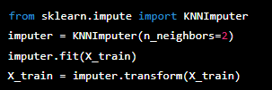

#### 1. Dataset with missing Values

```
a : [1, 2, 3, 4, 5, 6, 7, 8]
b : [1, 2, 3, 4, 5, None, None, None]
c : [1, None, None, None, 5, 6, 7, 8]
d : [1, 2, 3, 4, None, None, 7, 8]
e : [1, 2, 3, 4, 5, 6, None, None]
```

#### 2. Create a DataFrame from your data

|  | a | b | c | d | e |
| --- | --- | --- | --- | --- | --- |
| 0 | 1 | 1.0 | 1.0 | 1.0 | 1.0 |
| 1 | 2 | 2.0 | NaN | 2.0 | 2.0 |
| 2 | 3 | 3.0 | NaN | 3.0 | 3.0 |
| 3 | 4 | 4.0 | NaN | 4.0 | 4.0 |
| 4 | 5 | 5.0 | 5.0 | NaN | 5.0 |
| 5 | 6 | NaN | 6.0 | NaN | 6.0 |
| 6 | 7 | NaN | 7.0 | 7.0 | NaN |
| 7 | 8 | NaN | 8.0 | 8.0 | NaN |

#### 3. Create an instance of the KNNImputer

```
     a    b    c    d    e
0  1.0  1.0  1.0  1.0  1.0
1  2.0  2.0  1.0  2.0  2.0
2  3.0  3.0  1.0  3.0  3.0
3  4.0  4.0  1.0  4.0  4.0
4  5.0  5.0  5.0  1.0  5.0
5  6.0  1.0  6.0  1.0  6.0
6  7.0  1.0  7.0  7.0  1.0
7  8.0  1.0  8.0  8.0  1.0
```

### Reference

https://www.youtube.com/watch?v=zPG4NjIkCjc

https://www.youtube.com/watch?v=JvS2triCgOY&t=5s

https://www.youtube.com/watch?v=w2FKXOa0HGA

https://www.dataquest.io/blog/understanding-regression-error-metrics/

https://www.statology.org/machine-learning-tutorials/

https://www.aionlinecourse.com/tutorial/machine-learning/multiple-linear-regression

https://towardsdatascience.com/how-to-choose-the-best-linear-regression-model-a-comprehensive-guide-for-beginners-754480768467

https://data36.com/polynomial-regression-python-scikit-learn/

https://www.spiceworks.com/tech/artificial-intelligence/articles/what-is-linear-regression/